# Distributions discrètes

Probabilités et statistique pour la biologie (STAT1)

Jacques van Helden

2019-10-03

# Distribution de probabilité discrète

On parle de *distribution discrète* pour désigner la distribution de probabilité de variables ne pouvant prendre que des valeurs discrètes (par opposition aux distributions continues).

**Notes:**

- En probabilités la variable observée ($x$) représente généralement le nombre de succès d’une série d’observations. Elle prend donc généralement des valeurs naturelles ($x \in \mathbb{N}$).
- La probabilité $\operatorname{P}(x)$ prend des valeurs réelles entre 0 et 1, mais sa distribution est discrète puisqu’elle n’est définie que pour des valeurs discrètes de $x$. On la représente généralement par une fonction en escalier.

# Distribution géométrique

**Application:** temps d’attente jusqu’à la première réalisation d’un évènement au cours d’un schéma de Bernoulli.

**Exemples:**

- Comptage du nombre de jets d’un dé ($x$) qui précèdent la première occurrence d’un 6 (l’occurrence n’est pas incluse dans le compte).
- Longueur d’une séquence d’ADN avant la première occurrence d’une cytosine

# Fonction de masse de probabilité géométrique

La *fonction de masse de probabilité* (*Probability Mass Function*, *PMF*) indique la probabilité d’observer un résultat élémentaire particulier.

Pour la distribution géométrique, elle indique la probabilité d’observer exactement $x$ échecs avant le premier succès, au cours d’une série d’essais indépendants à probabilité de succès $p$.

$$\operatorname{P}(X = x) = (1-p)^x \cdot p$$

Justification:

- Probabilité d’échec pour un essai = $q = 1-p$ (évènements complémentaires)
- Schéma de Bernoulli $\rightarrow$ les essais sont indépendants $\rightarrow$ probabilité de la série est le produit des probabilités des résultats successifs.
- On calcule donc le produit des probabilité des $x$ échecs initiaux et du succès au $(x+1)^\text{ème}$ essai.

*Note: la PMF est apparentée au concept de **densité** que nous verrons lorsque nous traiterons les distributions continues.*

# Fonction de masse de probabilité géométrique

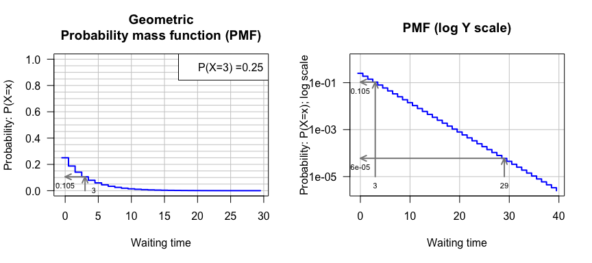

# Queues de distribution et fonction de répartition

Les queues de la distribution sont les aires comprises sous la courbe de densité jusqu’à une certaine valeur (*queue gauche*) ou à partir d’une certaine valeur (*queue droite*).

# Queues de distribution et fonction de répartition

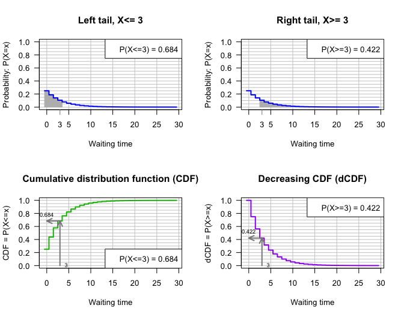

**Queues et fonction de répartition de probabilité géométrique**.

# Distribution binomiale

La **distribution binomiale** indique la probabilité d’observer un certain nombre ($x$) de succès au cours d’une série de $n$ essais indépendants avec une probabilité de succès $p$ constante (schéma de Bernoulli).

**Fonction de masse de probabilité binomiale**

$$\operatorname{P}(X=x) = \binom{n}{x} \cdot p^x \cdot (1-p)^{n-x} = C_n^x p^x (1-p)^{n-x} = \frac{n!}{x!(n-x)!} p^x (1-p)^{n-x}$$

**Fonction de répartition binomiale**

$$\operatorname{P}(X \ge x) = \sum_{i=x}^{n}{P(X=i)} = \sum_{i=x}^{n}{C_n^i p^i (1-p)^{n-i}}$$

**Propriétés**

- **Espérance** (nombre de succès attendus au hasard): $<X> = n \cdot p$
- **variance**: $\sigma^2 = n \cdot p \cdot (1 - p)$.
  - Note: la variance de la binomiale est inférieure à sa moyenne.
- **Ecart-type**: $\sigma = \sqrt{n \cdot p \cdot (1 - p)}$

# Distribution binomiale en $i$

La distribution binomiale peut prendre différentes formes selon les valeurs des paramètres (probabilité de succès $p$, et nombre d’essais $n$).

Quand l’espérance ($p \cdot n$) est inférieure à 1, la distribution est monotone décroissante, et on la qualifie de *distribution en forme de $i$*.

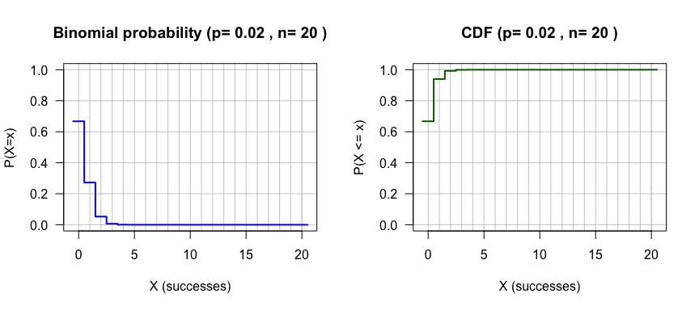

Distribution binomiale en forme de i.

# Distribution binomiale en cloche asymétrique

Quand la probabilité de succès relativement élevée mais inférieure à 0.5, la distribution prend une forme en cloche asymétrique.

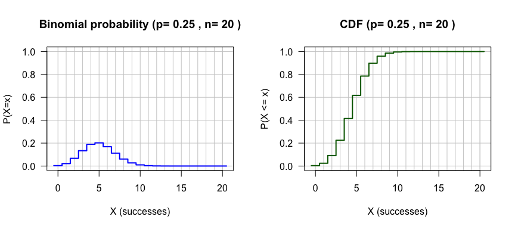

Distribution binomiale en forme de cloche asymétrique.